# More Statistical Concepts

Ziyuan Huang

Last Updated: 2025-12-04

# All of Statistics

- The Only Equation You Will Ever Need! (Field, Miles & Field, 2012)
- Everything in statistics essentially boils down to one equation:
- We fit models to our data, but we need to know how much error is associated.
- Often this process is called measuring fit - as the error should be small to conclude an accurate fit of the model to the data.

$$Outcome_i = (Model) +
error_i$$

- **This means:** the data we observe can be predicted from the model we choose to fit to the data plus some amount of error.
- The mean is the simplest statistical model - it’s a hypothetical value that summarizes our data.

# The Mean as a Statistical Model

- Consider an example: 5 statistics lecturers with the following number of friends: 1, 2, 3, 3, 4
- The mean is: (1 + 2 + 3 + 3 + 4)/5 = **2.6 friends**
- But 2.6 friends is impossible (unless you befriend someone’s arm!) - so the mean is a **hypothetical value**
- The mean is a **model** created to summarize our data
- Just like a bridge engineer uses a small-scale model to predict how a full-sized bridge behaves, we use sample statistics to infer about populations

# Measuring Fit

- Measuring the fit of your statistical model lets us know how well it represents reality.
- No statistical model is a perfect representation.
- For instance, mean is a model of what happens in the real world as the “typical score”.
- We assess models by comparing observed data to the model we’ve fitted (Field et al., 2012)
- First, let’s look at how to calculate multiple models at once with the `apply` family.

# Utilizing the Power of the ‘apply()’ Functions

- The `apply` family allows vectorized operations - faster and cleaner than loops
- **Modern alternative:** `dplyr` and `purrr` packages (tidyverse)
- **apply()**
  - Arguments = apply(X, MARGIN, FUN)
  - Objective = Apply a function to the rows (1) or columns (2)
  - Input = Data frame or matrix
  - Output = vector, list, array

```r
options(scipen = 20)
# Apply mean to each column (MARGIN = 2) of quakes dataset
round(apply(quakes, 2, mean), 2)
```

```
##      lat     long    depth      mag stations
##   -20.64   179.46   311.37     4.62    33.42
```

# Utilizing the Power of the ‘lapply’ Functions

- **lapply()** - “list apply”
  - Arguments = lapply(X, FUN)
  - Objective = Apply a function to all elements of the input
  - Input = List, vector or data frame
  - Output = **list** (always returns a list)

```r
# Returns a list - useful when outputs have different lengths
lapply(quakes, mean)
```

```
## $lat
## [1] -20.64275
##
## $long
## [1] 179.462
##
## $depth
## [1] 311.371
##
## $mag
## [1] 4.6204
##
## $stations
## [1] 33.418
```

# Utilizing the Power of the ‘sapply’ Functions

- **sapply()** - “simplified apply”
  - Arguments = sapply(X, FUN)
  - Same as lapply, but **simplifies** output when possible
  - Output = vector or matrix (if possible), otherwise list

```r
# Returns a named vector - cleaner for simple operations
round(sapply(quakes, mean), 2)
```

```
##      lat     long    depth      mag stations
##   -20.64   179.46   311.37     4.62    33.42
```

# Utilizing the Power of the ‘tapply’ Functions

- **tapply()** - “table apply”
  - Arguments = tapply(X, INDEX, FUN)
  - Objective = Apply function to groups defined by factor(s)
  - Perfect for group-wise calculations (like means by category)

```r
# Calculate mean magnitude by number of stations
head(tapply(quakes$mag,           # dependent variable
            list(quakes$stations), # grouping variable(s)
            mean),                 # function
     10)  # show first 10
```

```
##       10       11       12       13       14       15       16       17
## 4.230000 4.228571 4.196000 4.333333 4.276923 4.282353 4.274286 4.350000
##       18       19
## 4.436364 4.379310
```

# Modern Alternative: dplyr

```r
library(dplyr)

# Same calculations using tidyverse (more readable)
quakes |>
  group_by(stations) |>
  summarise(mean_mag = mean(mag),
            sd_mag = sd(mag),
            n = n()) |>
  head(10)
```

```
## # A tibble: 10 × 4
##    stations mean_mag sd_mag     n
##       <int>    <dbl>  <dbl> <int>
##  1       10     4.23  0.189    20
##  2       11     4.23  0.184    28
##  3       12     4.20  0.209    25
##  4       13     4.33  0.201    21
##  5       14     4.28  0.202    39
##  6       15     4.28  0.193    34
##  7       16     4.27  0.277    35
##  8       17     4.35  0.198    38
##  9       18     4.44  0.230    33
## 10       19     4.38  0.208    29
```

# Measuring Fit

- If we use the mean as our model, we may measure “fit” or error to the model by seeing how much scores vary around that mean.
- We can start by thinking about raw deviations:
  - **Definition** - a deviation is the difference between the mean and an actual data point.
  - They can be calculated by taking each score and subtracting the mean from it
    $$deviance = outcome_i - model_i$$

# Sum of Squared Errors

- We could then add the deviations to find out the total error.
- **Problem:** Deviations cancel out because they are centered around the mean: positive and negative values sum to zero.
- **Example (Field et al., 2012):** Lecturer friends: 1, 2, 3, 3, 4 with mean = 2.6
  - Deviations: (-1.6) + (-0.6) + (0.4) + (0.4) + (1.4) = **0** (but there IS error!)
- **Solution:** Square each deviation to remove negative signs
- **Sum of Squared Errors (SS)** = (-1.6)² + (-0.6)² + (0.4)² + (0.4)² + (1.4)² = **5.20**

$$SS = \sum_{i=1}^{n}(x_{i} -
\bar{x})^2$$

# From SS to Variance

- The SS is a good measure of accuracy, but it depends on the amount of data collected.
- **More data points = higher SS** (even if model fits equally well)
- To overcome this, we calculate the **average error** by dividing SS by degrees of freedom:

$$Variance (s^2) = \frac{SS}{N-1} =
\frac{\sum_{i=1}^{n}(x_{i} - \bar{x})^2}{N-1}$$

- For our lecturer example: Variance = 5.20 / 4 = **1.3 friends²**
- Problem: “friends squared” doesn’t make sense!
- **Solution:** Take the square root → **Standard Deviation** = √1.3 = **1.14 friends**

# Mean Squared Error

- Although the SS is a good measure of the accuracy of our model, it depends on the amount of data collected.
  - To overcome this problem, we calculate the average squared error:

$$MSE = \frac {SS} {df} = \frac
{\sum_{i=1}^{n}(outcome_i-model_i)^2} {N-1}$$

- This formula should look familiar - mean squared error is equivalent to the **variance**.
- **Critical distinction:**
  - For **populations** (when you have ALL data): divide by N
  - For **samples** (estimating population): divide by N-1 (degrees of freedom)
- Why N-1? Because we need to account for using our sample mean as an estimate of the population mean.

# Calculating Degrees of Freedom

- **Definition** - the number of values in a calculation that are free to vary.

**The Rugby Team Analogy (Field et al., 2012):**

- Imagine you’re a rugby team manager with 15 empty position slots
- When the 1st player arrives: you have **15 choices** for their position
- When the 2nd player arrives: you have **14 choices**
- … continue until 14 positions are filled…
- When the 15th player arrives: you have **NO choice** - only one position left!
- **Degrees of freedom = 15 - 1 = 14**

**In statistics:** If we use the sample mean to estimate the population mean, we hold one parameter constant. Only N-1 values are free to vary while keeping that mean constant.

# Calculating Errors - Summary

- Interpreting SD as a measure of model fit:
  - **Large SD (relative to mean)** = poor model fit - data points are distant from the mean
  - **Small SD (relative to mean)** = better model fit - data points cluster close to the mean
  - **SD = 0** would mean all scores were identical
  - Remember that SD is based on the scale of the variable
  - We use SD rather than variance because it’s in the original units (interpretable)
- **Visual insight:** A large standard deviation makes distributions look “fatter” and more spread out, while a small SD makes distributions look more “pointy” with scores clustered near the mean (Field et al., 2012)

# The Standard Error

- **Standard Deviation** tells us how well the mean represents the sample data.
- But what if we want to know how well the sample mean represents the **population mean**?
- Different samples from the same population will have slightly different means (**sampling variation**)
- The **Standard Error (SE)** is the standard deviation of sample means

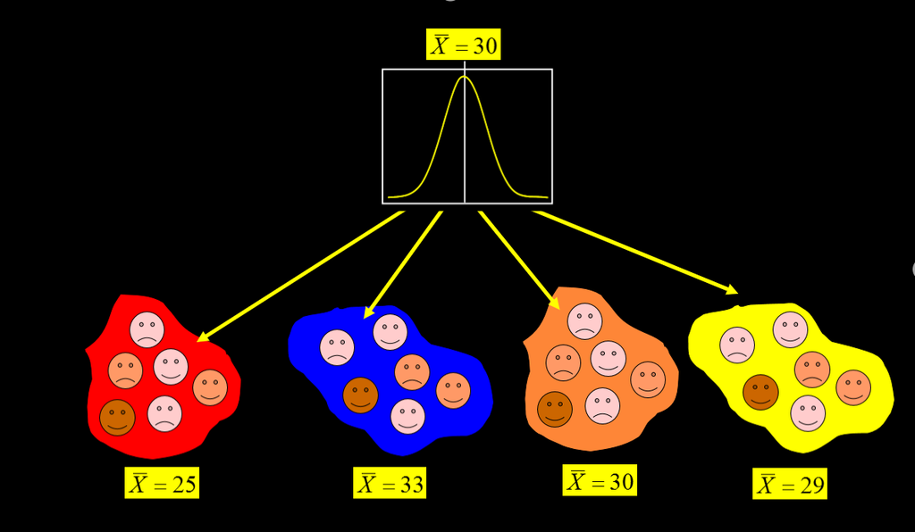

# Understanding the Standard Error

- **Key Distinction (Field et al., 2012):**
  - **Standard Deviation:** How much individual scores vary around the sample mean
  - **Standard Error:** How much sample means vary around the population mean
- **Interpretation:**
  - **Large SE** (relative to sample mean) = lots of variability between sample means → our sample might not be representative
  - **Small SE** = most sample means are similar to population mean → our sample is likely accurate

$$SE = \frac{s}{\sqrt{N}}$$

# Standard Error Applied

- The previous slides describe the concept of a **sampling distribution**.
- A sampling distribution is the frequency distribution of sample means from the same population.
- In real life, we don’t actually run multiple samples.

**Central Limit Theorem:**

- As sample size increases (N > 30), the sampling distribution of means approximates a **normal distribution**
- The mean of this distribution equals the population mean (μ)
- The SD of this distribution equals σ/√N

**Law of Large Numbers:**

- As sample size increases, the sample mean approaches the population mean

# Standard Error Applied

- Therefore, we can say that the mean approximates $\mu$ (the population mean) with large samples.
- However, the sampling distribution has a different dispersion than the sample distribution … so we can estimate the standard deviation of the sample distribution (standard error) by dividing by the square root of N from our one sample.
- The SD and the SE will tell you the same thing about model fit.

```r
psych::describe(quakes$mag)
```

```
##    vars    n mean  sd median trimmed  mad min max range skew kurtosis   se
## X1    1 1000 4.62 0.4    4.6    4.59 0.44   4 6.4   2.4 0.77      0.5 0.01
```

# Confidence Intervals

- **Definition** - a range of values within which we believe the population parameter falls, along with a probability that the interval correctly estimates the true value.

**The Japanese Quail Example (Field et al., 2012):**

- Sample mean sperm release = 17 million
- True population mean (unknown) = 15 million
- Wide interval (12-22 million): Contains true value ✓
- Narrow interval (16-18 million): Misses true value ✗
- The **level of confidence** (1 - α) is usually expressed as 95% or 99%
- A 95% CI means: if we collected 100 samples, approximately 95 of those CIs would contain the true population mean

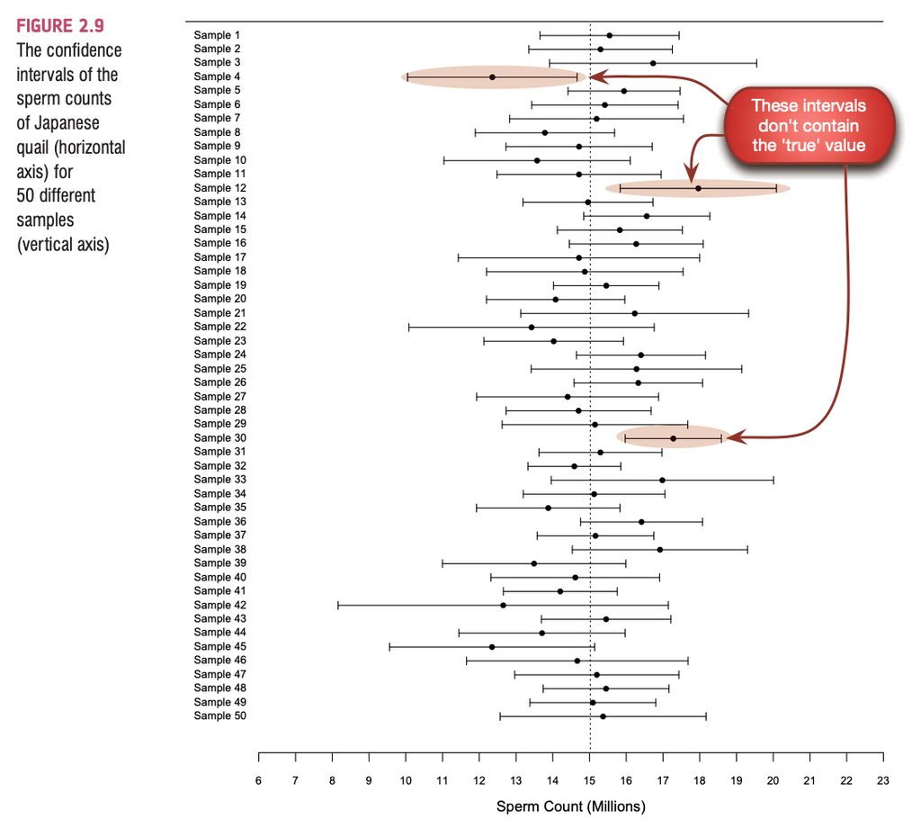

# Confidence Intervals for Z-scores

- Key z-score cutoffs: **±1.96** (95%) and **±2.58** (99%)
- For large samples (N > 30), we can use z-scores
- For small samples, use the **t-distribution** (which adjusts for sample size)

**Confidence Interval Formula:**

- **Upper limit:** $\bar{X} + (z \times SE)$
- **Lower limit:** $\bar{X} - (z \times SE)$

**Why use SE?** Because we’re estimating where the population mean falls, and SE tells us how much sample means vary from the population mean.

**Note:** The mean is always in the CENTER of the confidence interval. A narrow CI means our estimate is precise; a wide CI means uncertainty.

# Calculating Confidence Intervals

- We use z-score properties to set the confidence we seek.
- For large samples, z = 1.96 for 95% CI; z = 2.58 for 99% CI

```r
# Calculate means and standard errors for quakes dataset
M <- apply(quakes, 2, mean)
SE <- apply(quakes, 2, function(x) sd(x) / sqrt(length(x)))

# 95% Confidence Interval (using z = 1.96)
CI_95_lower <- M - 1.96 * SE
CI_95_upper <- M + 1.96 * SE

# Display results in a clean format
data.frame(
  Variable = names(M),
  Mean = round(M, 2),
  SE = round(SE, 2),
  CI_Lower = round(CI_95_lower, 2),
  CI_Upper = round(CI_95_upper, 2)
)
```

```
##          Variable   Mean   SE CI_Lower CI_Upper
## lat           lat -20.64 0.16   -20.95   -20.33
## long         long 179.46 0.19   179.09   179.84
## depth       depth 311.37 6.82   298.01   324.73
## mag           mag   4.62 0.01     4.60     4.65
## stations stations  33.42 0.69    32.06    34.78
```

# Modern R: Using tidyverse for CIs

```r
library(dplyr)
library(tidyr)

quakes |>
  summarise(across(everything(),
    list(mean = mean,
         se = ~sd(.x)/sqrt(length(.x))))) |>
  pivot_longer(everything(),
               names_to = c("variable", "stat"),
               names_sep = "_") |>
  pivot_wider(names_from = stat, values_from = value) |>
  mutate(CI_lower = mean - 1.96 * se,
         CI_upper = mean + 1.96 * se) |>
  mutate(across(where(is.numeric), ~round(.x, 2)))
```

```
## # A tibble: 5 × 5
##   variable   mean    se CI_lower CI_upper
##   <chr>     <dbl> <dbl>    <dbl>    <dbl>
## 1 lat      -20.6   0.16    -21.0   -20.3
## 2 long     179.    0.19    179.    180.
## 3 depth    311.    6.82    298.    325.
## 4 mag        4.62  0.01      4.6     4.65
## 5 stations  33.4   0.69     32.1    34.8
```

# Testing Hypotheses - (NHST)

- **The Null Hypothesis Significance Testing** involves drawing inferences about two contrasting propositions *(each called a hypothesis)* relating to population parameters.

**The Lady Tasting Tea (Fisher, 1925):**

- A woman claimed she could tell whether milk or tea was added first to a cup
- Fisher tested her with cups arranged in different orders
- With 2 cups: 50% chance of guessing correctly (not convincing!)
- With 6 cups: Only 5% chance of guessing correctly (1 in 20)
- Only when there’s a very small probability of success by chance should we believe it’s genuine

**The Framework:**

- H₀ (Null hypothesis): No effect exists (existing theory)
- H₁ (Alternative hypothesis): Effect does exist (complement of H₀)
- We either **reject H₀** (significant) or **fail to reject H₀** (not significant)
- **Important:** We never “accept” the null or “accept” the alternative!

# Why p < .05?

- Fisher (1925) suggested we should be **95% confident** before believing a result is genuine
- This means only a **5% chance** (p = .05) of the result occurring if H₀ is true
- **But Fisher himself warned:** “No scientific worker has a fixed level of significance at which from year to year, and in all circumstances, he rejects hypotheses; he rather gives his mind to each particular case in the light of his evidence and his ideas”

**The problem:** Critical values (.05, .02, .01) became popular because Fisher published tables for these specific values in his 1925 textbook - it was practical, not principled! (Field et al., 2012)

# Interpreting NHST

- **Does a significant result tell us the effect is important?**
  - **No!** Statistical significance ≠ practical importance
  - Very small, unimportant effects can be “significant” with large samples (Field & Hole, 2003)
- **Does a non-significant result prove the null is true?**
  - **No!** It only means the effect wasn’t large enough to detect
  - “The null hypothesis is never true” - Cohen (1990)
  - Even tiny differences (e.g., 10 vs 10.00001) are real differences!
- **Does a significant result prove the alternative is true?**
  - **No!** We’re using probabilistic reasoning
  - If p < .05, we’re saying “this is unlikely IF the null were true”
  - We cannot logically conclude “therefore the null is definitely false”

**The fundamental problem:** NHST encourages all-or-nothing thinking

# Test Statistics

- A test statistic has a **known frequency distribution** - we know how often different values occur
- Common test statistics: *t*, *F*, *χ²* (chi-square)
- The basic principle (Field et al., 2012):

$$Test\;Statistic =
\frac{systematic\;variation}{unsystematic\;variation} =
\frac{variance\;explained\;by\;model}{variance\;not\;explained\;by\;model}$$

**Interpretation:**

- If model is good → explains more variance than it can’t explain → test statistic > 1
- As test statistic gets **larger**, probability of occurring by chance gets **smaller**
- When p < .05, we conclude the model explains a sufficient amount of variation

**Analogy:** Like knowing the distribution of death ages - if someone is 110, we know that’s very unlikely (very small probability).

# Types of Tests

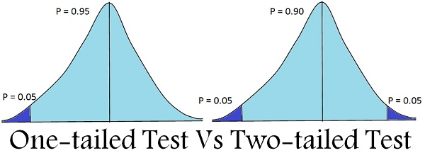

**Important:** You cannot change from two-tailed to one-tailed AFTER seeing the data!

# The Potential Errors

- **Hypothesis testing** can result in one of four different outcomes:
  1. H0 is true and the test correctly fails to reject H0
  2. H0 is false and the test correctly rejects H0
  3. H0 is true and the test incorrectly rejects H0 (called Type I error)
  4. H0 is false and the test incorrectly fails to reject H0 (called Type II error)

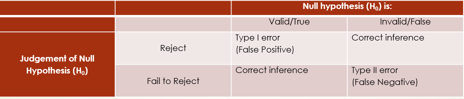

# Type I Errors

- **Type I Error (False Positive):** Rejecting H₀ when it’s actually true
- The probability of Type I error = **α** = P(rejecting H₀ | H₀ is true)
- Occurs when we conclude there’s a genuine effect when there isn’t
- **At α = .05:** If we replicate 100 times with NO real effect, we’d falsely detect an “effect” about 5 times

**The Trade-off:** Making α smaller (more conservative) reduces Type I errors but increases Type II errors

# Type II Errors

- **Type II Error (False Negative):** Failing to reject H₀ when it’s actually false
- The probability of Type II error = **β** = P(not rejecting H₀ | H₀ is false)
- Occurs when we miss a genuine effect that exists in the population
- **Cohen’s recommendation:** Maximum acceptable β = .20 (20%)
  - This means at most 1 in 5 genuine effects should be missed

# The Error Trade-off

[figure not shown]

**Key insight:** We cannot minimize both errors simultaneously. Reducing one increases the other.

# Power

- **Power** = Probability of detecting an effect that genuinely exists
- Power = 1 - β = P(rejecting H₀ | H₀ is false)
- **Cohen’s recommendation:** Aim for power ≥ .80 (80% chance of detecting real effects)

**Four interconnected quantities:**

1. Sample size (N)
2. Effect size in the population
3. Alpha level (α)
4. Power (1 - β)

**Key principle:** Knowing any three, you can calculate the fourth!

# Power of the Test

- **Power is influenced by:**
  - **Effect size:** Larger effects are easier to detect
    - SD (smaller = more power)
    - Mean differences (larger = more power)
  - **Alpha level:** Larger α = more power (but more Type I errors)
  - **Type of test:** One-tailed tests have more power (but riskier)
  - **Sample size:** Larger N = more power (most practical lever)

**Cohen’s (1992) guidelines for N with α = .05 and power = .80:**

- Small effect (r = .1): Need **783** participants
- Medium effect (r = .3): Need **85** participants
- Large effect (r = .5): Need **28** participants

# Effect Sizes

- **The Solution to NHST Problems** (Field et al., 2012)
- Just because a test is “significant” doesn’t mean the effect is important!
- An **effect size** is a standardized measure of the magnitude of an observed effect

**Why effect sizes matter:**

- **Standardized** = comparable across studies (meta-analysis)
- **Not dependent on sample size** (unlike p-values)
- **Allows objective evaluation** of the practical importance of findings
- **APA recommends** reporting effect sizes in all publications

# Why Not Just Use p-values?

- p-values depend heavily on **sample size**
- With N = 10,000, even trivially small effects become “significant”
- A “significant” effect might explain only 0.1% of variance - is that meaningful?
- **Effect sizes give context** that p-values lack

**Field et al. (2012):** “The use of effect sizes strikes a balance between using arbitrary cut-off points such as p < .05 and assessing whether an effect is meaningful within the research context.”

# Effect Size Measures

- There are **several effect size measures** that can be used:
  - **Cohen’s d** - standardized mean difference (good for comparing groups)
  - **Pearson’s r** - correlation coefficient (versatile, bounded 0-1)
  - **Glass’ Δ** - uses control group SD only
  - **Hedges’ g** - corrects Cohen’s d for small samples
  - **R²** - proportion of variance explained
  - **Odds Ratio** - for categorical outcomes

**Field’s preference:** Pearson’s r because it’s constrained between 0 (no effect) and 1 (perfect effect)

**Note:** r is not linear - r = .6 is not twice as big as r = .3!

# Cohen’s Effect Size Guidelines

- **r = .10, d = .20 (small effect):**
  - The effect explains **1%** of the total variance
  - Example: Barely noticeable difference
- **r = .30, d = .50 (medium effect):**
  - The effect accounts for **9%** of the total variance
  - Example: Visible to careful observation
- **r = .50, d = .80 (large effect):**
  - The effect accounts for **25%** of the variance
  - Example: Obvious and substantial

**Important caveat (Baguley, 2004; Lenth, 2001):**

- These are “canned” guidelines - not absolute rules
- Effect size should be evaluated **within the research context**
- A “small” effect on mortality might be hugely important!
- A “large” effect on trivial outcomes might be meaningless

# Controlling for Multiple Comparisons

- **Family-wise error rate (FWER):** Probability of making one or more Type I errors across multiple tests
- **Experiment-wise error rate:** Proportion of experiments with at least one Type I error

**Common corrections:**

- **Bonferroni:** Divide α by number of comparisons (conservative)
- **Šidák-Bonferroni:** Slightly less conservative than Bonferroni
- **Tukey HSD:** For all pairwise comparisons
- **Scheffé:** Most conservative, for complex comparisons
- **Holm:** Step-down procedure (more powerful than Bonferroni)
- **Benjamini-Hochberg (FDR):** Controls false discovery rate (more lenient)

# Example of an Effect Size

```r
library(MOTE)

# Calculate group statistics using tapply
M <- tapply(quakes$mag, quakes$stations, mean)
STDEV <- tapply(quakes$mag, quakes$stations, sd)
N <- tapply(quakes$mag, quakes$stations, length)

# View first few means
head(M)
```

```
##       10       11       12       13       14       15
## 4.230000 4.228571 4.196000 4.333333 4.276923 4.282353
```

```r
# Compare station 10 to 11 using Cohen's d for independent samples
effect <- d.ind.t(m1 = M[1], m2 = M[2],
                  sd1 = STDEV[1], sd2 = STDEV[2],
                  n1 = N[1], n2 = N[2], a = .05)

cat("Cohen's d =", effect$d, "\n")
```

```
## Cohen's d = 0.007661913
```

```r
cat("Interpretation:",
    ifelse(abs(as.numeric(effect$d)) < 0.2, "negligible",
    ifelse(abs(as.numeric(effect$d)) < 0.5, "small",
    ifelse(abs(as.numeric(effect$d)) < 0.8, "medium", "large"))), "effect")
```

```
## Interpretation: negligible effect
```

# Modern R: Using effectsize Package

```r
# Alternative using effectsize package (more modern approach)
library(effectsize)

# Create a simple comparison
group1 <- quakes$mag[quakes$stations <= 20]
group2 <- quakes$mag[quakes$stations > 20 & quakes$stations <= 40]

# Calculate Cohen's d with confidence interval
cohens_d(group1, group2)
```

```
## Cohen's d |         95% CI
## --------------------------
## -1.08     | [-1.24, -0.93]
##
## - Estimated using pooled SD.
```

# Summary

In this section, you’ve learned about:

- **Model Fit:** The fundamental equation: Outcome = Model + Error
- **Deviance, SS, Variance, SD:** How we measure how well the mean represents data
- **Degrees of Freedom:** The rugby team analogy - N-1 values free to vary
- **Standard Error:** How well our sample mean estimates the population mean
- **Confidence Intervals:** Ranges where population parameters likely fall
- **NHST:** Lady Tasting Tea, p < .05, and what significance really means
- **Type I & II Errors:** False positives, false negatives, and the trade-off
- **Power:** Probability of detecting real effects (aim for ≥ .80)
- **Effect Sizes:** Cohen’s d and r - measuring practical importance

# Key Takeaways

1. **Everything is Model + Error** - this is the foundation of statistics
2. **Statistical significance ≠ practical importance** - always report effect sizes
3. **The null is never exactly true** - Cohen (1990)
4. **p < .05 is arbitrary** - Fisher chose it for convenience, not principle
5. **Sample size matters** for power, not just for significance
6. **Use confidence intervals** - they tell you more than p-values alone

# References

- Cohen, J. (1988, 1992). Statistical power analysis for the behavioral sciences.
- Cohen, J. (1990). Things I have learned (so far). *American Psychologist, 45*(12), 1304-1312.
- Cohen, J. (1994). The earth is round (p < .05). *American Psychologist, 49*(12), 997-1003.
- Field, A., Miles, J., & Field, Z. (2012). *Discovering statistics using R*. SAGE Publications.
- Fisher, R. A. (1925/1991). *Statistical methods for research workers*.